# GLM & GAM

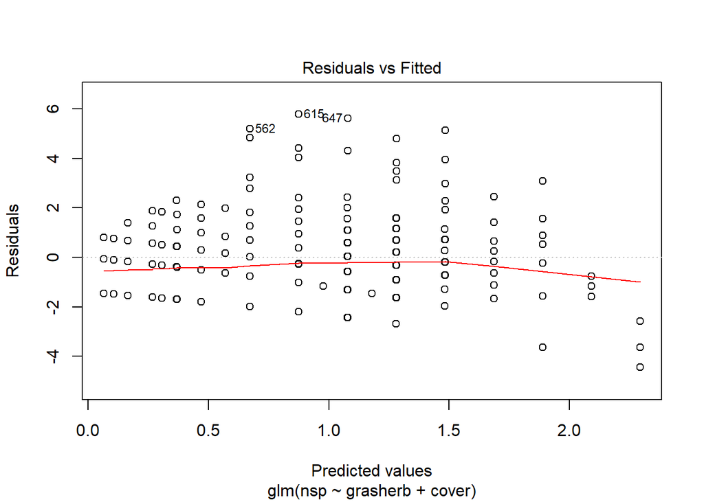

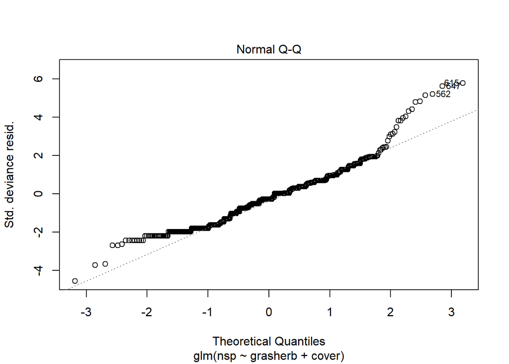

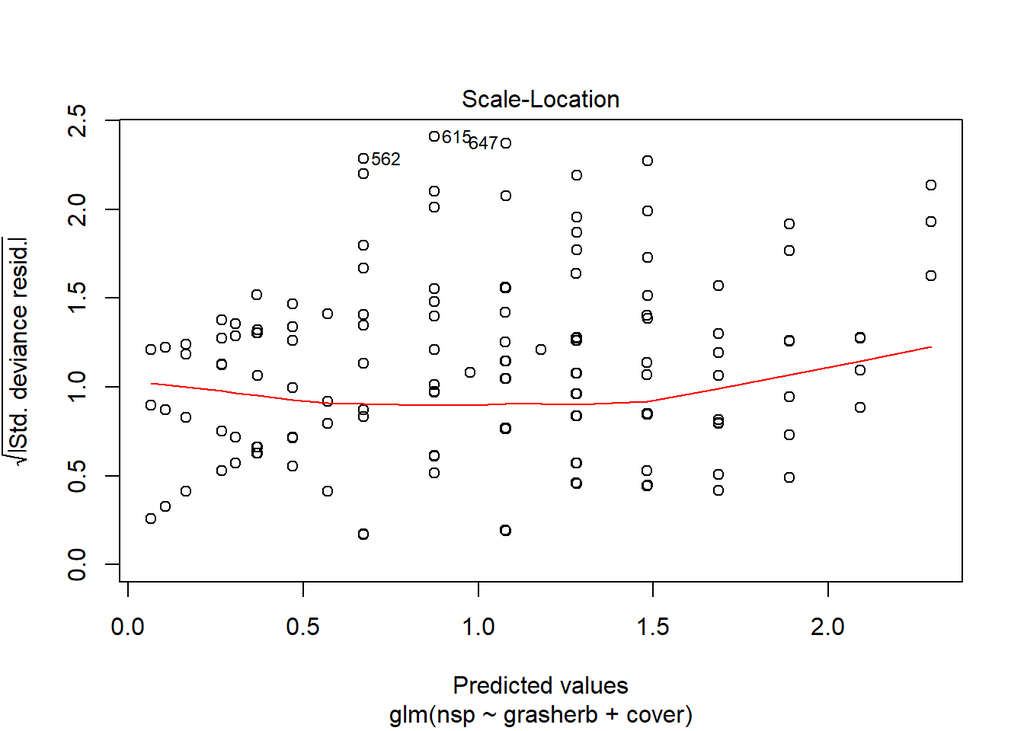

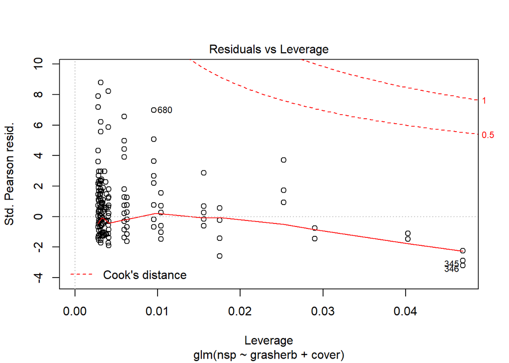

```r
plot (fit.herb.glm)
```

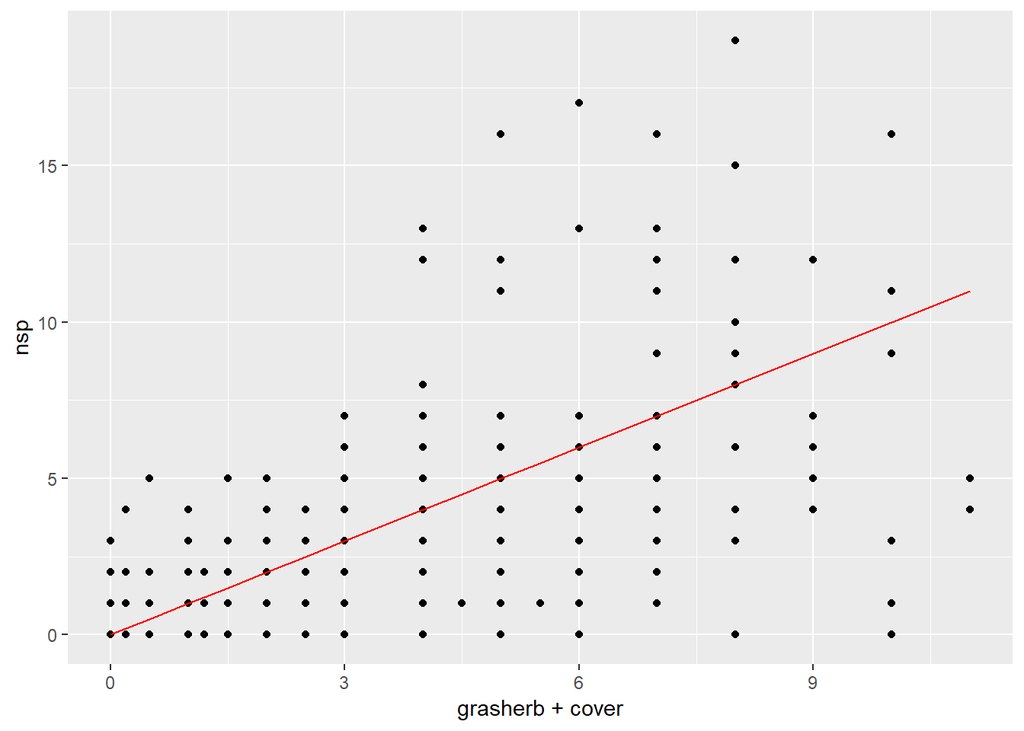

```r
ggplot(cbind(sorich, fit = fitted(fit.herb.glm)), aes(x = grasherb+ cover, y = nsp)) +
  geom_point() +
  geom_line(aes(y = grasherb+cover), colour = "red")
```

```r
anova (fit.sorich.glm)
```

```
## Analysis of Deviance Table
##
## Model: poisson, link: log
##
## Response: nsp
##
## Terms added sequentially (first to last)
##
##
##       Df Deviance Resid. Df Resid. Dev
## NULL                    691     1660.9
## cover  1   345.95       690     1315.0
```

```r
anova(fit.herb.glm)
```

```
## Analysis of Deviance Table
##
## Model: poisson, link: log
##
## Response: nsp
##
## Terms added sequentially (first to last)
##
##
##          Df Deviance Resid. Df Resid. Dev
## NULL                       691     1660.9
## grasherb  1    17.42       690     1643.5
## cover     1   345.95       689     1297.6
```

## How much does over-dispersion affect results

1. Use `sample()` to randomise the response in sorich to remove the relationship between the preictor and response. Sample reorders the vector. We took the column nsp and randomized. We use the dollar sign to indicate that is a colum inside the sorich. We randomized the nsp so we null the relationship between predictor and response.

```r
random.sorich <- tibble (nsp = sample(sorich$nsp), cover = sorich$cover)
random.sorich
```

```
## # A tibble: 692 x 2
##      nsp cover
##    <int> <dbl>
##  1     2   0
##  2     1   0
##  3     8   0
##  4     4   0
##  5     0   0
##  6     6   0
##  7    12   0
##  8     2   0
##  9     0   0
## 10     0   0.2
## # ... with 682 more rows
```

2. Test if a Poisson GLM with cover as a predictor is significant.

Since the response is random, it might or not be significant.

```r
glm.random.sorich <- glm(nsp ~ cover, data = random.sorich, family = poisson)
anova(glm.random.sorich)
```

```
## Analysis of Deviance Table
##
## Model: poisson, link: log
##
## Response: nsp
##
## Terms added sequentially (first to last)
##
##
##       Df Deviance Resid. Df Resid. Dev
## NULL                    691     1660.9
## cover  1   0.0481       690     1660.9
```

```r
summary (glm.random.sorich)
```

```
##
## Call:
## glm(formula = nsp ~ cover, family = poisson, data = random.sorich)
##
## Deviance Residuals:
##     Min       1Q   Median       3Q      Max
## -2.2398  -1.0777  -0.3206   0.3271   6.6501
##
## Coefficients:
##              Estimate Std. Error z value Pr(>|z|)
## (Intercept)  0.919615   0.045766  20.094   <2e-16 ***
## cover       -0.002668   0.012173  -0.219    0.827
## ---
## Signif. codes:  0 '***' 0.001 '**' 0.01 '*' 0.05 '.' 0.1 ' ' 1
##
## (Dispersion parameter for poisson family taken to be 1)
##
##     Null deviance: 1660.9  on 691  degrees of freedom
## Residual deviance: 1660.9  on 690  degrees of freedom
## AIC: 3215
##
## Number of Fisher Scoring iterations: 5
```

3. Repeat 1000 times and find the distribution of p-values. Although the data is randomized, I found a significant relation and that is a proof of over dispersion. The function tidy also gives the intercept value, so I need to filter it out with filter(term ==“cover”). With glance, on lm, I don´t need to do that.

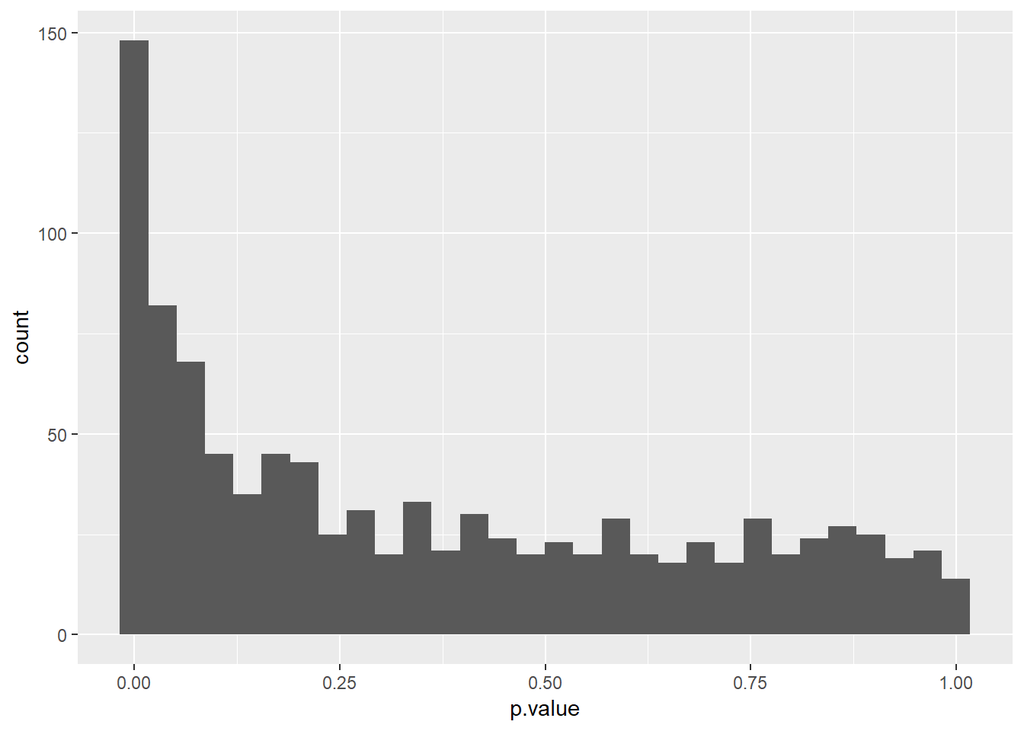

```r
rerun(.n=1000, tibble (nsp = sample(sorich$nsp), cover = sorich$cover)) %>%
  map (~ glm(nsp~cover, data = ., family = poisson())) %>%
  map_df (tidy) %>%  filter(term == "cover") %>%
  ggplot (aes(x=p.value)) + geom_histogram()
```

## Binomial GAM

1. Open library mgcv
2. Import data pot.csv

```r
pot <- read.csv("~/Project A1 BIO302/pot.csv")
pot
```

```
##     alt potalp
## 1    50      0
## 2   375      0
## 3    90      0
## 4   155      0
## 5   125      0
## 6   190      0
## 7    70      0
## 8    90      0
## 9    30      0
## 10   30      0
## 11   30      0
## 12   25      0
## 13   60      0
## 14  100      0
```

[output cut: 557 more lines]

3. What type of distribution is the response variable?

Binomial

4. What type of link-function do we use?

5. Do an appropriate GLM analysis? The + I(alt^2) is quadratic, so it will make a curve.

```r
pot.glm <- glm(potalp ~ alt + I(alt^2), data = pot, family = binomial)
anova(pot.glm)
```

```
## Analysis of Deviance Table
##
## Model: binomial, link: logit
##
## Response: potalp
##
## Terms added sequentially (first to last)
##
##
##          Df Deviance Resid. Df Resid. Dev
## NULL                       570     550.92
## alt       1   0.0088       569     550.91
## I(alt^2)  1  21.6270       568     529.28
```

```r
summary (pot.glm)
```

```
##
## Call:
## glm(formula = potalp ~ alt + I(alt^2), family = binomial, data = pot)
##
## Deviance Residuals:
##     Min       1Q   Median       3Q      Max
## -0.8291  -0.7198  -0.5613  -0.4035   2.2524
##
## Coefficients:
##               Estimate Std. Error z value Pr(>|z|)
## (Intercept) -2.705e+00  3.579e-01  -7.557 4.13e-14 ***
## alt          2.454e-02  6.126e-03   4.007 6.15e-05 ***
## I(alt^2)    -8.304e-05  2.180e-05  -3.809  0.00014 ***
## ---
## Signif. codes:  0 '***' 0.001 '**' 0.01 '*' 0.05 '.' 0.1 ' ' 1
##
## (Dispersion parameter for binomial family taken to be 1)
##
##     Null deviance: 550.92  on 570  degrees of freedom
## Residual deviance: 529.28  on 568  degrees of freedom
## AIC: 535.28
##
## Number of Fisher Scoring iterations: 5
```

6. Interpret the results?

There is no over dispersion, observing residuals and DF.

7. Do a GAM analysis

```r
pot.gam <- gam(potalp ~ s(alt), data = pot, family = binomial)
anova (pot.gam)
```

```
##
## Family: binomial
## Link function: logit
##
## Formula:
## potalp ~ s(alt)
##
## Approximate significance of smooth terms:
##          edf Ref.df Chi.sq p-value
## s(alt) 4.061  5.033  17.32 0.00398
```

8. Compare the GLM and GAM models.

```r
anova (pot.glm, pot.gam, test ="Chisq")
```

```
## Analysis of Deviance Table
##
## Model 1: potalp ~ alt + I(alt^2)
## Model 2: potalp ~ s(alt)
##   Resid. Df Resid. Dev     Df Deviance Pr(>Chi)
## 1    568.00     529.28
## 2    565.94     525.35 2.0608   3.9306   0.1471
```

```r
summary (pot.glm)
```

```
##
## Call:
## glm(formula = potalp ~ alt + I(alt^2), family = binomial, data = pot)
##
## Deviance Residuals:
##     Min       1Q   Median       3Q      Max
## -0.8291  -0.7198  -0.5613  -0.4035   2.2524
##
## Coefficients:
##               Estimate Std. Error z value Pr(>|z|)
## (Intercept) -2.705e+00  3.579e-01  -7.557 4.13e-14 ***
## alt          2.454e-02  6.126e-03   4.007 6.15e-05 ***
## I(alt^2)    -8.304e-05  2.180e-05  -3.809  0.00014 ***
## ---
## Signif. codes:  0 '***' 0.001 '**' 0.01 '*' 0.05 '.' 0.1 ' ' 1
##
## (Dispersion parameter for binomial family taken to be 1)
##
##     Null deviance: 550.92  on 570  degrees of freedom
## Residual deviance: 529.28  on 568  degrees of freedom
## AIC: 535.28
##
## Number of Fisher Scoring iterations: 5
```

```r
summary (pot.gam)
```

```
##
## Family: binomial
## Link function: logit
##
## Formula:
## potalp ~ s(alt)
##
## Parametric coefficients:
##             Estimate Std. Error z value Pr(>|z|)
## (Intercept)  -1.5856     0.1229   -12.9   <2e-16 ***
## ---
## Signif. codes:  0 '***' 0.001 '**' 0.01 '*' 0.05 '.' 0.1 ' ' 1
##
## Approximate significance of smooth terms:
##          edf Ref.df Chi.sq p-value
## s(alt) 4.061  5.033  17.32 0.00398 **
## ---
## Signif. codes:  0 '***' 0.001 '**' 0.01 '*' 0.05 '.' 0.1 ' ' 1
##
## R-sq.(adj) =  0.0307   Deviance explained = 4.64%
## UBRE = -0.062215  Scale est. = 1         n = 571
```

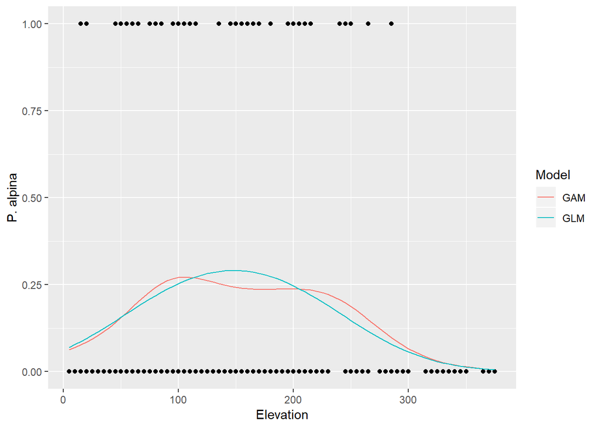

```r
ggplot(cbind(pot, fit.gam = fitted(pot.gam), fit.glm = fitted(pot.glm)), aes(alt, potalp)) +
  geom_point() +
  geom_line(aes(y = fit.gam, colour = "GAM")) +
  geom_line(aes(y = fit.glm, colour = "GLM")) +
  labs(x = "Elevation", y = "P. alpina", colour = "Model")
```

9. Which model would you prefer, and why?

This was the ANOVA output:

Model 1: potalp ~ alt + I(alt^2) Model 2: potalp ~ s(alt) Resid. Df Resid. Dev Df Deviance Pr(>Chi) 1 568.00 529.28  
2 565.94 525.35 2.0608 3.9306 0.1471

the Pr (>Chi) shows that the models are not significantly different, so the choice should go to GLM. Although GAM has a easier plot to read, the GLM is easier to interpret the results and the coeficient, and to measure the highest point in the curve.